# McDonalds India - EDA

R Sangole

Aug 1, 2022

# Introduction

# Initial Setup

*Read through the initial setup in the 4 tabs below.*

## Libraries

First, some I import some useful libraries and set some plotting defaults.

```r
# Data Manipulation
library(dplyr)
library(tidyr)
library(readr)
library(skimr)
library(purrr)
library(stringr)
library(urltools)
library(magrittr)

# Plots
library(ggplot2)
library(naniar)
library(packcircles)
library(ggridges)
library(ggbeeswarm)
library(patchwork)

# Tables
library(reactable)

# Settings
theme_set(theme_minimal(
  base_size = 13,
  base_family = "Menlo"))
theme_update(
  plot.title.position = "plot"
)
```

## Read In

Let’s start be reading in the data…

```r
dat <- read_csv("../input/mcdonalds-india-menu-nutrition-facts/India_Menu.csv") %>%
  janitor::clean_names()
glimpse(dat, 100)
```

```
## Rows: 141
## Columns: 13
## $ menu_category        <chr> "Regular Menu", "Regular Menu", "Regular Menu", "Regular Menu", "Regu…
## $ menu_items           <chr> "McVeggie™ Burger", "McAloo Tikki Burger®", "McSpicy™ Paneer Burger",…
## $ per_serve_size       <chr> "168 g", "146 g", "199 g", "250 g", "177 g", "306 g", "132 g", "87 g"…
## $ energy_k_cal         <dbl> 402.05, 339.52, 652.76, 674.68, 512.17, 832.67, 356.09, 228.21, 400.8…
## $ protein_g            <dbl> 10.24, 8.50, 20.29, 20.96, 15.30, 24.17, 7.91, 5.45, 15.66, 15.44, 21…
## $ total_fat_g          <dbl> 13.83, 11.31, 39.45, 39.10, 23.45, 37.94, 15.08, 11.44, 15.70, 14.16,…
## $ sat_fat_g            <dbl> 5.34, 4.27, 17.12, 19.73, 10.51, 16.83, 6.11, 5.72, 5.47, 5.79, 7.63,…
## $ trans_fat_g          <dbl> 0.16, 0.20, 0.18, 0.26, 0.17, 0.28, 0.24, 0.09, 0.16, 0.21, 0.18, 0.2…
## $ cholesterols_mg      <dbl> 2.49, 1.47, 21.85, 40.93, 25.24, 36.19, 9.45, 5.17, 31.17, 32.83, 66.…
## $ total_carbohydrate_g <dbl> 56.54, 50.27, 52.33, 59.27, 56.96, 93.84, 46.36, 24.79, 47.98, 38.85,…
## $ total_sugars_g       <dbl> 7.90, 7.05, 8.35, 3.50, 7.85, 11.52, 4.53, 2.73, 5.53, 5.58, 5.88, 2.…
## $ added_sugars_g       <dbl> 4.49, 4.07, 5.27, 1.08, 4.76, 6.92, 1.15, 0.35, 4.49, 3.54, 4.49, 1.0…
## $ sodium_mg            <dbl> 706.13, 545.34, 1074.58, 1087.46, 1051.24, 1529.22, 579.60, 390.74, 7…
```

## Quick View

```r
skimr::skim(dat)
```

Data summary

| Name | dat |
| --- | --- |
| Number of rows | 141 |
| Number of columns | 13 |
| _______________________ |  |
| Column type frequency: |  |
| character | 3 |
| numeric | 10 |
| ________________________ |  |
| Group variables | None |

**Variable type: character**

| skim_variable | n_missing | complete_rate | min | max | empty | n_unique | whitespace |
| --- | --- | --- | --- | --- | --- | --- | --- |
| menu_category | 0 | 1 | 11 | 15 | 0 | 7 | 0 |
| menu_items | 0 | 1 | 8 | 42 | 0 | 141 | 0 |
| per_serve_size | 0 | 1 | 3 | 9 | 0 | 107 | 0 |

**Variable type: numeric**

| skim_variable | n_missing | complete_rate | mean | sd | p0 | p25 | p50 | p75 | p100 | hist |
| --- | --- | --- | --- | --- | --- | --- | --- | --- | --- | --- |
| energy_k_cal | 0 | 1.00 | 244.64 | 185.55 | 0 | 116.36 | 219.36 | 339.52 | 834.36 | ▇▇▃▁▁ |
| protein_g | 0 | 1.00 | 7.49 | 8.34 | 0 | 0.65 | 4.79 | 10.88 | 39.47 | ▇▃▁▁▁ |
| total_fat_g | 0 | 1.00 | 9.99 | 10.34 | 0 | 0.46 | 7.77 | 14.16 | 45.18 | ▇▅▂▁▁ |
| sat_fat_g | 0 | 1.00 | 5.00 | 4.90 | 0 | 0.28 | 4.27 | 7.28 | 20.46 | ▇▅▂▁▁ |
| trans_fat_g | 0 | 1.00 | 0.69 | 6.33 | 0 | 0.06 | 0.15 | 0.22 | 75.26 | ▇▁▁▁▁ |
| cholesterols_mg | 0 | 1.00 | 26.35 | 50.33 | 0 | 1.51 | 8.39 | 31.11 | 302.61 | ▇▁▁▁▁ |
| total_carbohydrate_g | 0 | 1.00 | 31.19 | 20.60 | 0 | 15.74 | 30.82 | 46.00 | 93.84 | ▇▇▆▂▁ |
| total_sugars_g | 0 | 1.00 | 15.46 | 15.69 | 0 | 2.33 | 9.16 | 26.95 | 64.22 | ▇▂▂▁▁ |
| added_sugars_g | 0 | 1.00 | 10.34 | 14.28 | 0 | 0.00 | 3.64 | 19.23 | 64.22 | ▇▂▁▁▁ |
| sodium_mg | 1 | 0.99 | 362.06 | 473.16 | 0 | 43.90 | 152.02 | 534.24 | 2399.49 | ▇▂▁▁▁ |

## Data Quality

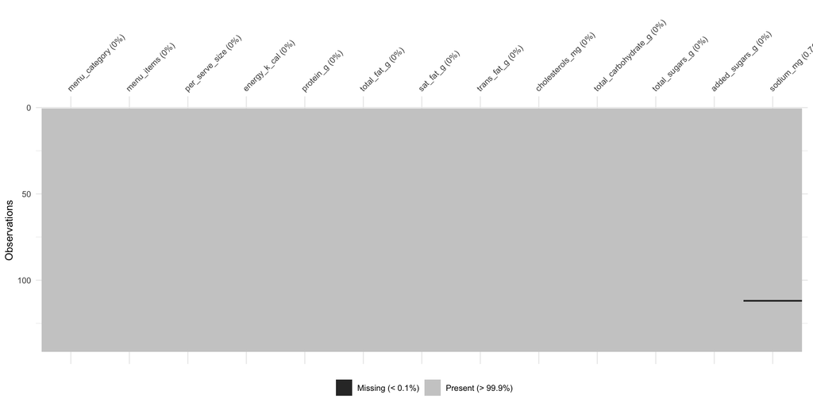

```r
dat %>%
  vis_miss()
```

# Interesting Questions

Since this is an open ended exploration, I’d like to posit some questions which will guide the flow of further work.

1. Which are the unhealthiest menu options, measured in terms of total fat content, total sugar, cholesterol, or sodium?
2. Which are the most and least energy dense options?
3. How does the Gourmet Menu differ from the Regular Menu?
4. What patterns or clusters exist, if any, which can give us a clearer picture of this menu?

# Feature Development

To aid answering many of these, I first need to create a few new features in the data set.

## Serving Size

The serving size by default is a character, with the units (g) embedded in the column. Let’s clean this up.

```r
dat <- dat %>%
  mutate(per_serve_size = as.numeric(stringr::str_extract(per_serve_size, "\\d*"))) %>%
  rename(per_serve_size_g = per_serve_size)
glimpse(dat, 80)
```

```
## Rows: 141
## Columns: 13
## $ menu_category        <chr> "Regular Menu", "Regular Menu", "Regular Menu", "…
## $ menu_items           <chr> "McVeggie™ Burger", "McAloo Tikki Burger®", "McSp…
## $ per_serve_size_g     <dbl> 168, 146, 199, 250, 177, 306, 132, 87, 173, 136, …
## $ energy_k_cal         <dbl> 402.05, 339.52, 652.76, 674.68, 512.17, 832.67, 3…
## $ protein_g            <dbl> 10.24, 8.50, 20.29, 20.96, 15.30, 24.17, 7.91, 5.…
## $ total_fat_g          <dbl> 13.83, 11.31, 39.45, 39.10, 23.45, 37.94, 15.08, …
## $ sat_fat_g            <dbl> 5.34, 4.27, 17.12, 19.73, 10.51, 16.83, 6.11, 5.7…
## $ trans_fat_g          <dbl> 0.16, 0.20, 0.18, 0.26, 0.17, 0.28, 0.24, 0.09, 0…
## $ cholesterols_mg      <dbl> 2.49, 1.47, 21.85, 40.93, 25.24, 36.19, 9.45, 5.1…
## $ total_carbohydrate_g <dbl> 56.54, 50.27, 52.33, 59.27, 56.96, 93.84, 46.36, …
## $ total_sugars_g       <dbl> 7.90, 7.05, 8.35, 3.50, 7.85, 11.52, 4.53, 2.73, …
## $ added_sugars_g       <dbl> 4.49, 4.07, 5.27, 1.08, 4.76, 6.92, 1.15, 0.35, 4…
## $ sodium_mg            <dbl> 706.13, 545.34, 1074.58, 1087.46, 1051.24, 1529.2…
```

## Calorie Counts

```r
dat <- dat %>%
  mutate(
    cal_cat = case_when(
      energy_k_cal <= 200 ~ "Low",
      energy_k_cal > 200 & energy_k_cal <= 400 ~ "Medium",
      energy_k_cal > 400 & energy_k_cal <= 600 ~ "High",
      energy_k_cal > 600 ~ "Very High"
    ),
    cal_cat = factor(cal_cat, levels = c("Very High", "High", "Medium", "Low"), ordered = TRUE)
  )
glimpse(dat, 80)
```

```
## Rows: 141
## Columns: 14
## $ menu_category        <chr> "Regular Menu", "Regular Menu", "Regular Menu", "…
## $ menu_items           <chr> "McVeggie™ Burger", "McAloo Tikki Burger®", "McSp…
## $ per_serve_size_g     <dbl> 168, 146, 199, 250, 177, 306, 132, 87, 173, 136, …
## $ energy_k_cal         <dbl> 402.05, 339.52, 652.76, 674.68, 512.17, 832.67, 3…
## $ protein_g            <dbl> 10.24, 8.50, 20.29, 20.96, 15.30, 24.17, 7.91, 5.…
## $ total_fat_g          <dbl> 13.83, 11.31, 39.45, 39.10, 23.45, 37.94, 15.08, …
## $ sat_fat_g            <dbl> 5.34, 4.27, 17.12, 19.73, 10.51, 16.83, 6.11, 5.7…
## $ trans_fat_g          <dbl> 0.16, 0.20, 0.18, 0.26, 0.17, 0.28, 0.24, 0.09, 0…
## $ cholesterols_mg      <dbl> 2.49, 1.47, 21.85, 40.93, 25.24, 36.19, 9.45, 5.1…
## $ total_carbohydrate_g <dbl> 56.54, 50.27, 52.33, 59.27, 56.96, 93.84, 46.36, …
## $ total_sugars_g       <dbl> 7.90, 7.05, 8.35, 3.50, 7.85, 11.52, 4.53, 2.73, …
## $ added_sugars_g       <dbl> 4.49, 4.07, 5.27, 1.08, 4.76, 6.92, 1.15, 0.35, 4…
## $ sodium_mg            <dbl> 706.13, 545.34, 1074.58, 1087.46, 1051.24, 1529.2…
## $ cal_cat              <ord> High, Medium, Very High, Very High, High, Very Hi…
```

# Graphical EDA

Now that I have the data sets prepared and ready, it’s time for the fun part - being creative and creating some interesting visuals!

```r
make_dot_violin_plot <- function(dat,
                                 title = NULL,
                                 xlab = NULL,
                                 ylab = NULL,
                                 subtitle = NULL,
                                 he_width = 0.5,
                                 he_alpha = 0.7,
                                 pt_size = 4,
                                 pt_width = 0.2,
                                 pt_alpha = 0.5){
  dat %>%
  ggplot(aes(
    x = forcats::fct_reorder(
      str_wrap(colorby, 10), -y),
    y = y
  )) +
  ggdist::stat_halfeye(
    aes(thickness = stat(f * n)),
    width = he_width,
    position = position_nudge(x = .2),
    alpha = he_alpha
  ) +
  geom_quasirandom(
    aes(color = cat),
    size = pt_size,
    width = pt_width,
    alpha = pt_alpha,
    varwidth = TRUE
  ) +
  ggtitle(title) +
  labs(
    x = xlab,
    y = ylab,
    subtitle = subtitle
  )
}
```

## Unhealthiest Menu Options

*Q: Which are the unhealthiest menu options, measured in terms of total fat content, total sugar, cholesterol, or sodium?*

### Fat Content

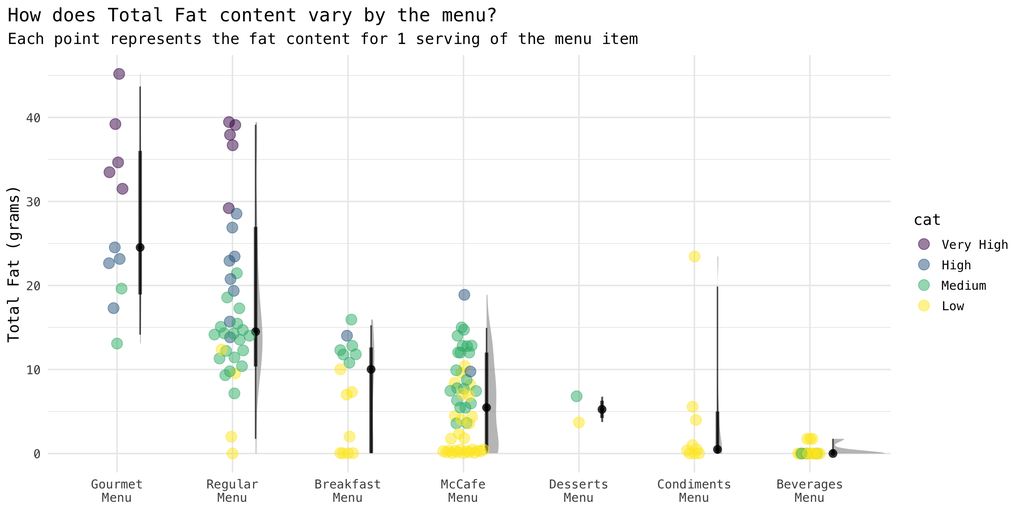

```r
dat %>%
  select(y = total_fat_g, cat = cal_cat, colorby = menu_category) %>%
  make_dot_violin_plot(
    title = "How does Total Fat content vary by the menu?",
    ylab = "Total Fat (grams)",
    subtitle = "Each point represents the fat content for 1 serving of the menu item"
  )
```

### Sugar Content

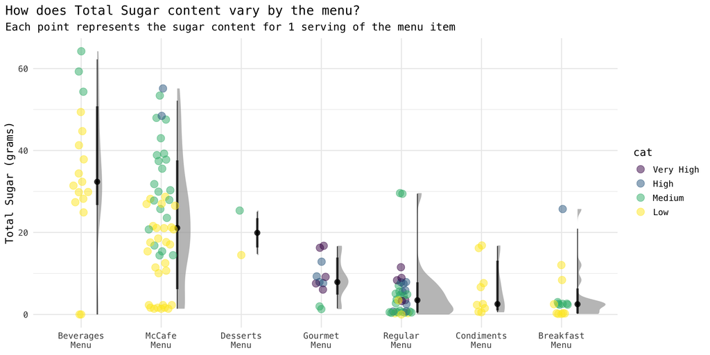

```r
dat %>%
  select(y = total_sugars_g, cat = cal_cat, colorby = menu_category) %>%
  make_dot_violin_plot(
    title = "How does Total Sugar content vary by the menu?",
    ylab = "Total Sugar (grams)",
    subtitle = "Each point represents the sugar content for 1 serving of the menu item"
  )
```

### Sodium Content

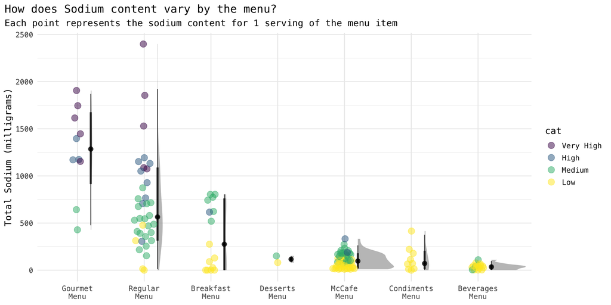

```r
dat %>%
  select(y = sodium_mg, cat = cal_cat, colorby = menu_category) %>%
  tidyr::drop_na() %>%
  make_dot_violin_plot(
    he_width = .6,
    title = "How does Sodium content vary by the menu?",
    ylab = "Total Sodium (milligrams)",
    subtitle = "Each point represents the sodium content for 1 serving of the menu item"
  )
```

### Cholesterol Content

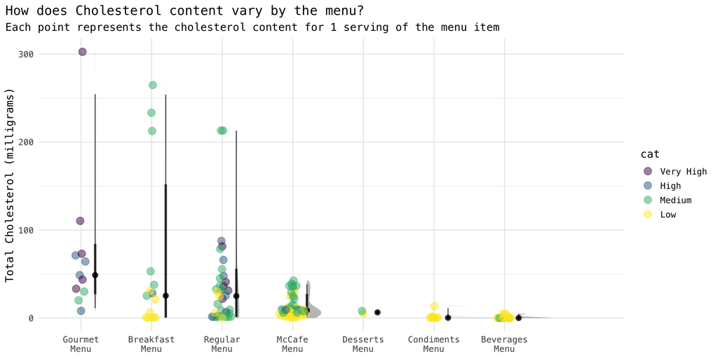

```r
dat %>%
  select(y = cholesterols_mg, cat = cal_cat, colorby = menu_category) %>%
  make_dot_violin_plot(
    he_width = 1.5,
    title = "How does Cholesterol content vary by the menu?",
    ylab = "Total Cholesterol (milligrams)",
    subtitle = "Each point represents the cholesterol content for 1 serving of the menu item"
  )
```

### Carbohydrate Content

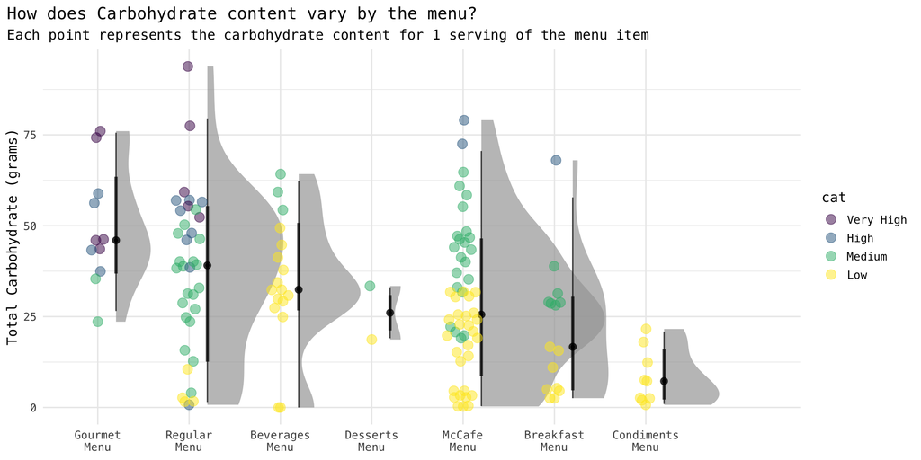

```r
dat %>%
  select(y = total_carbohydrate_g, cat = cal_cat, colorby = menu_category) %>%
  make_dot_violin_plot(
    he_width = 1.5,
    title = "How does Carbohydrate content vary by the menu?",
    ylab = "Total Carbohydrate (grams)",
    subtitle = "Each point represents the carbohydrate content for 1 serving of the menu item"
  )
```

That’s it for now. I’ll keep updating this EDA as I find time and think of more questions to explore.

Thanks for reading!